# Practical Machine Learning Course Project

Xiaolong He

October 25, 2017

## Load and clean the data:

```r
library(caret)
training <- read.csv("pml-training.csv")
testing <- read.csv("pml-testing.csv")

# Delete columns that contain more than 95% NAs or blanks
n <- nrow(training)
training.n <- training
for (v in names(training)) {
   if( sum(is.na(training[, v]))/n > 0.95 | sum(training[, v]=="")/n > 0.95)
       training.n[, v] <- NULL
}
training <- training.n

# delete the first six columns because they should not be relevant to the response classes
training[, 1:6]=NULL
```

## Explore the data

### Visualize the data

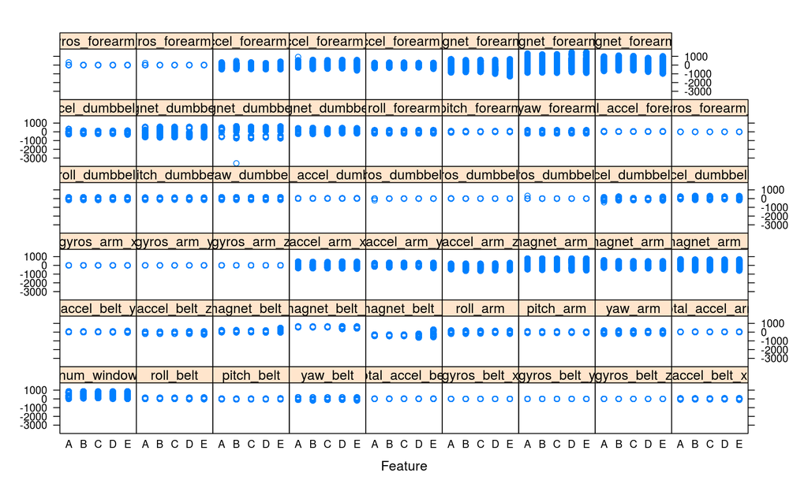

```r
featurePlot(training[, -54], y=training$classe)
```

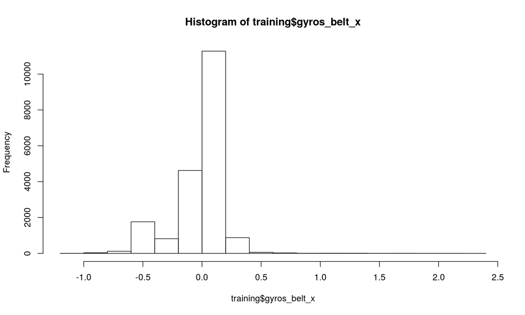

```r
hist(training$gyros_belt_x)
```

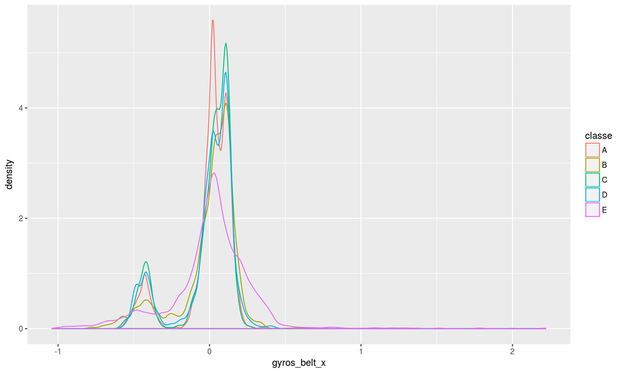

```r
qplot(gyros_belt_x, colour=classe, data=training, geom="density")
```

Shown above are just some examples of data exploration. No obvious patterns can be observed that suggest some relationship between any predictor and the response classes.

### check correlations between predictors

```r
M <- abs(cor(training[,-54]))
diag(M) <- 0
cbind(which(M>0.8, arr.ind=T), cor=M[which(M>0.8, arr.ind=T)])
```

```
##                  row col       cor
## yaw_belt           4   2 0.8152297
## total_accel_belt   5   2 0.9809241
## accel_belt_y      10   2 0.9248983
## accel_belt_z      11   2 0.9920085
## accel_belt_x       9   3 0.9657334
## magnet_belt_x     12   3 0.8841727
## roll_belt          2   4 0.8152297
## roll_belt          2   5 0.9809241
## accel_belt_y      10   5 0.9278069
## accel_belt_z      11   5 0.9749317
## pitch_belt         3   9 0.9657334
## magnet_belt_x     12   9 0.8920913
## roll_belt          2  10 0.9248983
## total_accel_belt   5  10 0.9278069
## accel_belt_z      11  10 0.9333854
## roll_belt          2  11 0.9920085
## total_accel_belt   5  11 0.9749317
## accel_belt_y      10  11 0.9333854
## pitch_belt         3  12 0.8841727
## accel_belt_x       9  12 0.8920913
## gyros_arm_y       20  19 0.9181821
## gyros_arm_x       19  20 0.9181821
## magnet_arm_x      25  22 0.8142732
## accel_arm_x       22  25 0.8142732
## magnet_arm_z      27  26 0.8144455
## magnet_arm_y      26  27 0.8144455
## accel_dumbbell_x  35  29 0.8082885
## accel_dumbbell_z  37  30 0.8491322
## gyros_dumbbell_z  34  32 0.9789507
## gyros_forearm_z   47  32 0.9144764
## gyros_dumbbell_x  32  34 0.9789507
## gyros_forearm_z   47  34 0.9330422
## pitch_dumbbell    29  35 0.8082885
## yaw_dumbbell      30  37 0.8491322
## gyros_forearm_z   47  46 0.8455626
## gyros_dumbbell_x  32  47 0.9144764
## gyros_dumbbell_z  34  47 0.9330422
## gyros_forearm_y   46  47 0.8455626
```

It can be seen that some predictors are highly correlated.

## Training the data with tree-based models

Since the dependent variable is a category variable, tree-based models are tested to train the data.

### Try rpart modeling. k-fold (k=3) cross-validation is used in data training

```r
library(caret)
set.seed(12345)
mdl.rpart1 <- train(classe ~ ., data=training, method="rpart", trControl=trainControl(method = "cv", number = 3))
#plot(mdl.rpart1$finalModel)
#text(mdl.rpart1$finalModel, use.n=TRUE, all=TRUE, cex=.8)
mdl.rpart1$results
```

```
##           cp  Accuracy      Kappa AccuracySD    KappaSD
## 1 0.03891896 0.5450950 0.41559612 0.04804504 0.06964358
## 2 0.05998671 0.4090927 0.19622692 0.07482610 0.12476412
## 3 0.11515454 0.3387455 0.08279854 0.04703180 0.07171618
```

The results of this modeling are quite poor. The highest accuracy is only 0.54.

Because some predictors are highly correlated, it may be helpful to have the data preprocessed with pca:

```r
set.seed(12345)
mdl.rpart2 <- train(classe ~ ., data=training, preProcess = "pca", method="rpart", trControl=trainControl(method = "cv", number = 3))
mdl.rpart2$results
```

```
##           cp  Accuracy    Kappa   AccuracySD    KappaSD
## 1 0.03891896 0.3785040 0.182214 9.888184e-03 0.01932934
## 2 0.05998671 0.3432348 0.111831 2.320580e-02 0.04594010
## 3 0.11515454 0.2843747 0.000000 6.641848e-05 0.00000000
```

The results show that pre-processing the data with principal component analysis harms the modeling.

### Try bagging

```r
set.seed(12345)
mdl.bag2 <- train(classe ~ ., data=training, method="treebag")
mdl.bag2
```

```
## Bagged CART
##
## 19622 samples
##    53 predictors
##     5 classes: 'A', 'B', 'C', 'D', 'E'
##
## No pre-processing
## Resampling: Bootstrapped (25 reps)
## Summary of sample sizes: 19622, 19622, 19622, 19622, 19622, 19622, ...
## Resampling results:
##
##   Accuracy   Kappa
##   0.9941673  0.992621
```

Bagging substantially improves the accuracy of decision tree model.

### Try Random Forest modeling

```r
set.seed(12345)
mdl.rf1 <- train(classe ~ ., data=training, method="rf", trControl=trainControl(method = "oob"))
mdl.rf1
```

```
## Random Forest
##
## 19622 samples
##    53 predictors
##     5 classes: 'A', 'B', 'C', 'D', 'E'
##
## No pre-processing
## Resampling results across tuning parameters:
##
##   mtry  Accuracy   Kappa
##    2    0.9970441  0.9962612
##   27    0.9987259  0.9983885
##   53    0.9966874  0.9958098
##
## Accuracy was used to select the optimal model using  the largest value.
## The final value used for the model was mtry = 27.
```

```r
mdl.rf1$finalModel
```

```
##
## Call:
##  randomForest(x = x, y = y, mtry = param$mtry)
##                Type of random forest: classification
##                      Number of trees: 500
## No. of variables tried at each split: 27
##
##         OOB estimate of  error rate: 0.15%
## Confusion matrix:
##      A    B    C    D    E  class.error
## A 5578    1    0    0    1 0.0003584229
## B    7 3787    2    1    0 0.0026336582
## C    0    5 3417    0    0 0.0014611338
## D    0    0    9 3206    1 0.0031094527
## E    0    0    0    2 3605 0.0005544774
```

This modeling gives excellent results. Both accuracies and Kappa values are higher than 99%. Overall out of sample error rate is o.15%. Therefore, it is used to predict the classes of test dataset.

### Predict the classes of testing dataset

```r
# Delete the columns that are not used for training
testing.n <- testing[, names(testing) %in% names(training)]
pred.test <- predict(mdl.rf1$finalModel, newdata=testing.n)
pred.test
```

```
##  1  2  3  4  5  6  7  8  9 10 11 12 13 14 15 16 17 18 19 20
##  B  A  B  A  A  E  D  B  A  A  B  C  B  A  E  E  A  B  B  B
## Levels: A B C D E
```

**The accuracy of the prediction of the test dataset is 100% according to the quiz grade.**